# Good_Bad_Markdown

Amanda

3/21/2021

# Load Libraries

```r
library(tidyverse)
library(here)
library(wesanderson)
```

# Save the Data

```r
data("ChickWeight") #taken from r datasets (version 3.6.2)
ChickData<-ChickWeight
ChickData%>%
write_csv(here("Good_Bad_Plot", "Data", "ChickData.csv")) # save the dataset I am using to my folder
```

# Making a Bad Plot

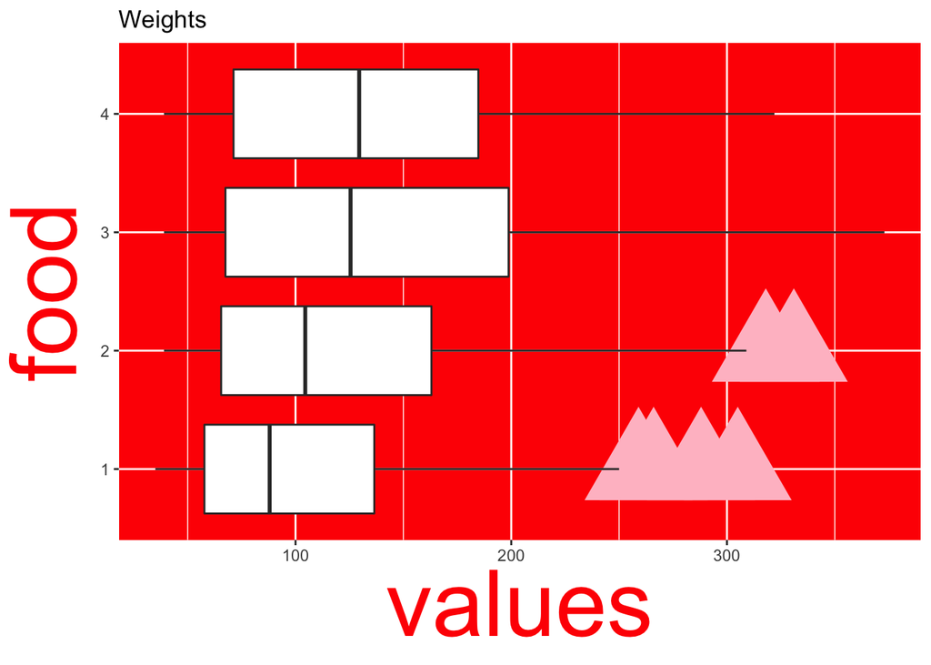

```r
Chick_bad_plot <- ChickData %>% # this is the data set we will be using
ggplot(aes(x = weight, y = Diet)) + # indicate which variable on each axis
  geom_boxplot(outlier.colour="pink", outlier.shape=17,
             outlier.size=20) + # make a boxplot, indicate outlier color, shape and size
  labs(title = "Weights", # title your plot
       x = "values", # name x axis
       y = "food")+ # re-name the y axis
  theme(axis.title = element_text(size = 50, color = "red"), # change axis label color and size
        panel.background = element_rect(fill = "red")) # change the background of the plot
Chick_bad_plot # wow that is ugly
```

**What Makes it a Bad Plot:**  
- Tasteless (Hard to read and even know what the plot is intended to show)  
- No description or figure caption of plot anywhere  
- The background is too bright, makes it difficult to read (too much constrast)  
- Background has lines (would be cleaner without)  
- X and Y axis do not have captions or units of measurement  
- Title is not descriptive and is not centered  
- The outliers are a random shape and they are too large to correctly view  
- Without a jitterplot over the boxplots, it is hard to truly read and understand the data

# Making a Good Plot

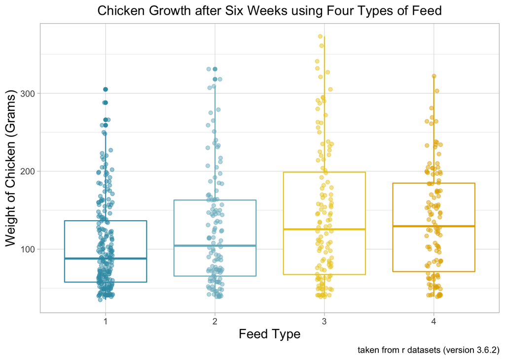

Figure 2. An experiment was conducted to measure and compare the effectiveness of various feed supplements on the growth rate of chickens.

```r
pal <- wes_palette("Zissou1") # save the appropriate pallet for the plot

Chick_good_plot <- ChickData %>% #name the plot
ggplot(aes(x = Diet, # format x axis # indicate x and y axis data
             y = weight,
           color = Diet))+ # make each variable a different color
  geom_boxplot(show.legend = FALSE) + # make a boxplot
  geom_jitter(show.legend = FALSE, alpha=0.5, # add jitterplot
              position = position_jitterdodge(
              jitter.width = NULL,
              jitter.height = 0,
              dodge.width = 0.75))+
  labs(title = "Chicken Growth after Six Weeks using Four Types of Feed", # title plot something clear and easy to understand
       x = "Feed Type", # label x axis
       y = "Weight of Chicken (Grams)", # label y axis (with units)
       caption = "taken from r datasets (version 3.6.2)")+ # add figure caption for more information on origin of data
  theme_light()+ # change theme, remove background color etc.
  theme(axis.title = element_text(size = 13), # change text size
        plot.title = element_text(hjust = 0.5))+ # center the title
  scale_color_manual(values = pal) # change the color pallet (this time we are using wes anderson colors)
Chick_good_plot # better!
```

**What Makes it a Good Plot:**  
- The title is clear and indicates what the plot is showing  
- Colors make the data “pop”  
- the X and Y axis are both labeled, and give units when appropriate  
- there is a figure caption at the bottom giving more information about the plot and data origin  
- the background is a light color, and there are minimal distraction to the data  
- the addition of the jitterplot (raw data points) to the plot help the viewer to understand the spread of the data in a clear way  
- each feed type is indicated by a different color, but the colors are neutral and easy to follow  
- Not a high level of contrast in the colors, makes it nicer to look at